# Exploratory Data Analysis & US Gun Violence

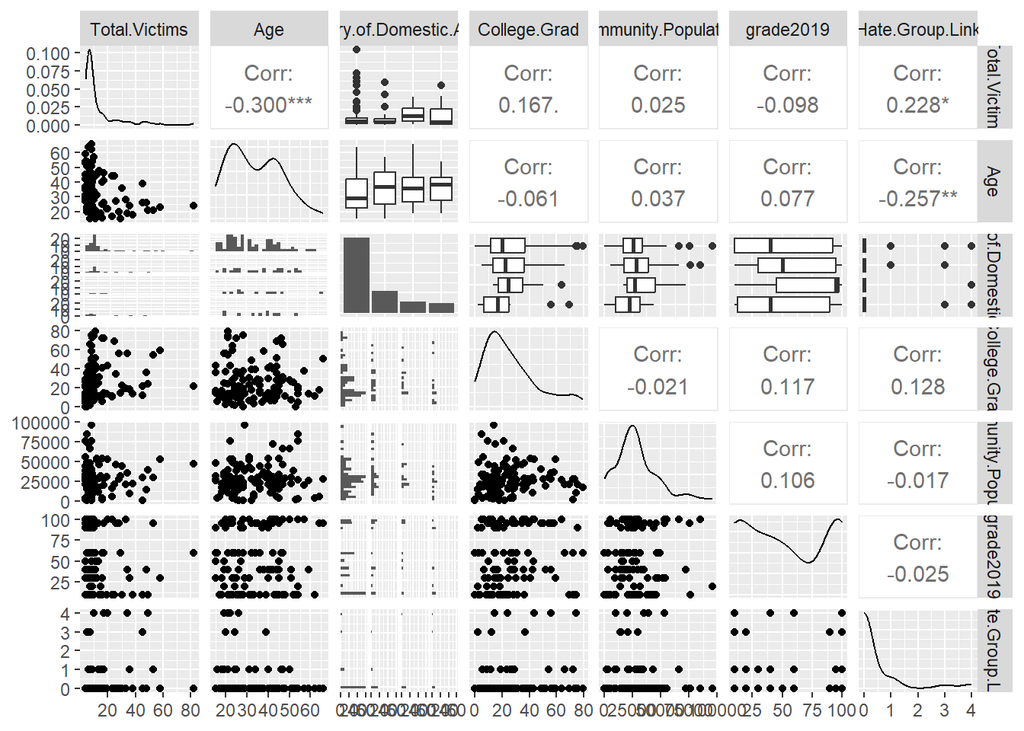

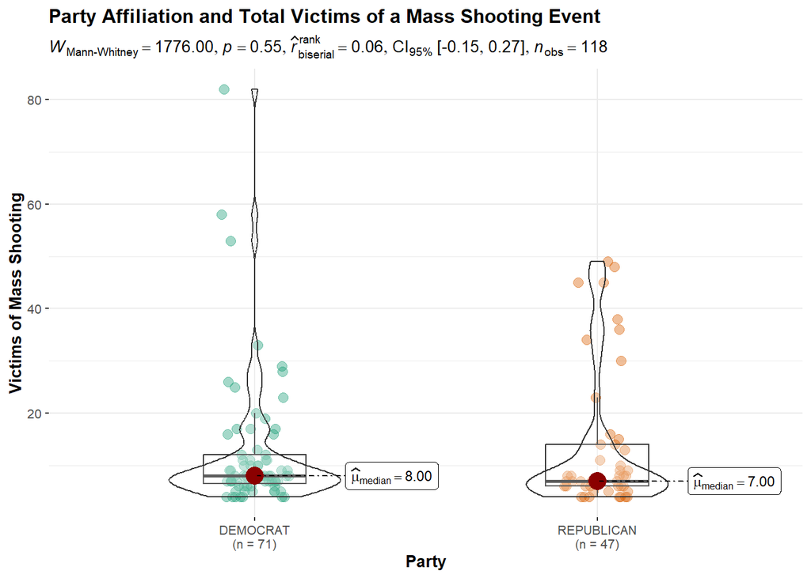

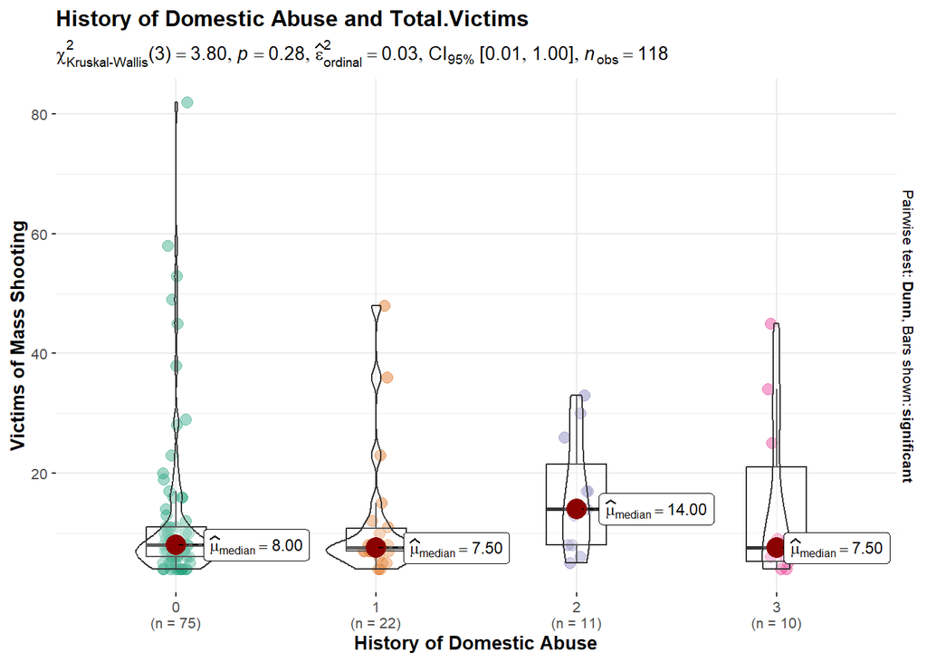

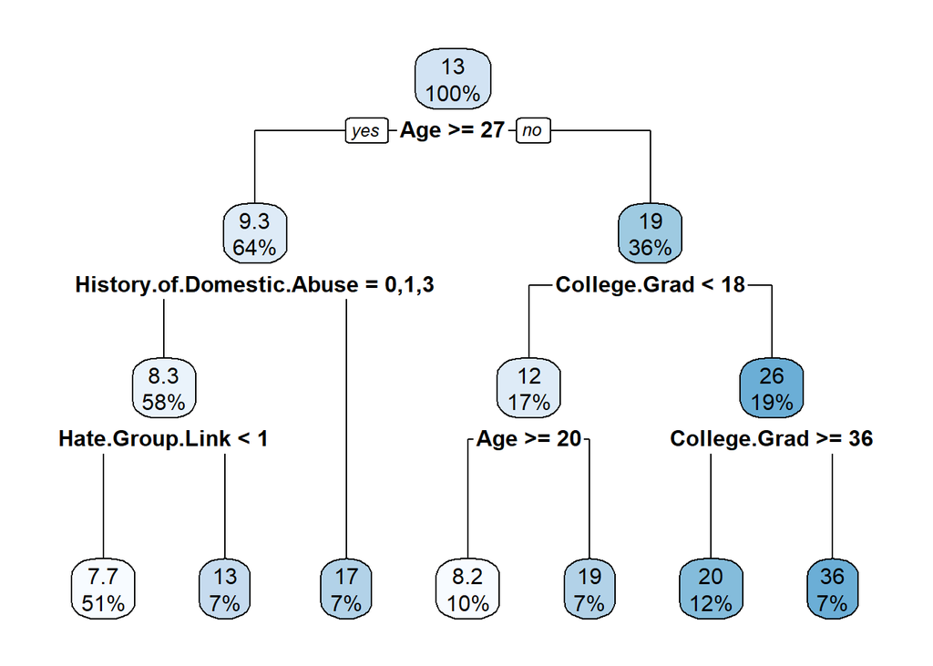

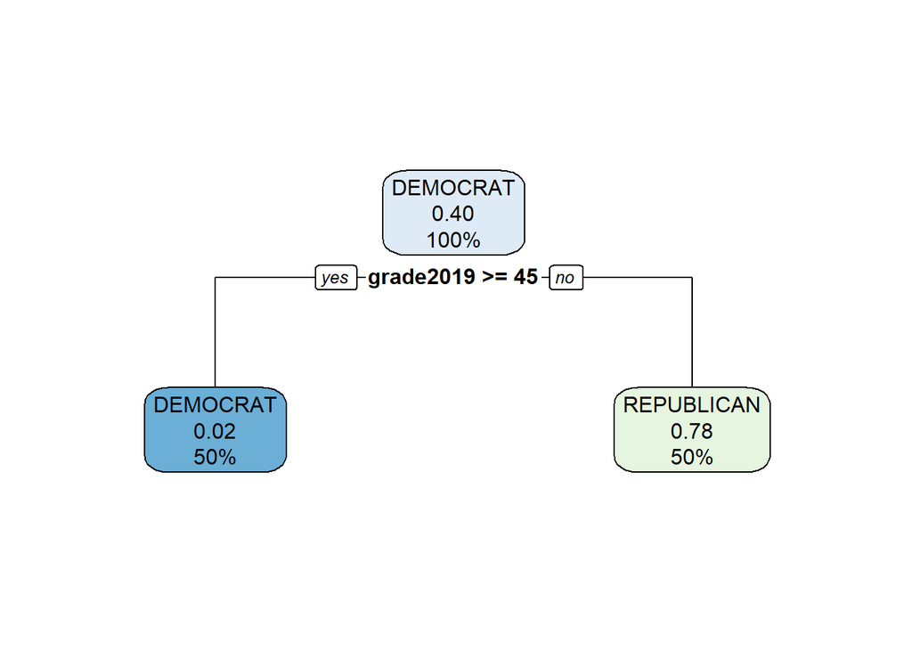

## Ethical Concerns

As is the case with sensitive material such as a mass shooting database, there are several ethical concerns with the usage of this data. First and foremost, this dataset was obtained via request to the Violence Project who have restricted the publishing and publicaly presenting of any analysis undertaken without their explicit permission. From an analysis perspective, it was also an ethical (and moral consideration in my opinion) that the names of both the perpetrators and victims be unmentioned as they are all available in the main database. Though I omitted including the specific city of where each event occurred I did use the community population, the year, month and day of each event which can be traced back to each location. This was done deliberately as I was curious to see what variables best explained the violent nature of each mass shooting event.

Finally, there is a final point about gun control and how results of this analysis may impact how people view this hugely contested issue. Looking at the face value of the results of this analysis, it shows that gun laws did not correlate with a change in the number of victims of a mass shooting event. This result may make someone inclined to think that gun laws are therefore, not effective. This kind of analysis may be sound (ish), but not valid. Gun laws do work. This analysis did not look at frequency of gun violence and gun law strictness because that work is already established and has shown to work in reducing gun violence. **This work ONLY looked at events once they had already occurred**. To reduce overall violent nature of mass shootings, reducing the overall frequency of shootings is an incredibly effective method and this analysis should not be viewed as something that goes against gun laws and creating new gun laws.

Thank you for reading, if you want to check out more of my work click here to go back to the homepage.